# **Longitudinal Outcome Monitoring and Assessment of Multi-Sectoral Climate Resilience, Biodiversity Conservation, and Inclusive Education Interventions** *Annual Outcome Assessment (AOA) — 2024*

Ecosystems Restoration and Resilient Development in the Chittagong Hill Tracts (ERRD-CHT) Programme — *Synthetic Data Demonstration · Portfolio Project*

Author

Affiliation

MD. Kamrul Hasan

DM WATCH LIMITED — Monitoring, Evaluation and Learning Consultancy

Published

June 19, 2026

**WarningNote on Data — Please Read Before Citing**

This report is an **independently produced demonstration and portfolio project**. All survey data presented were **synthetically generated** using parameterized statistical distributions calibrated against published literature, census benchmarks, and programme documentation from the CHT region (see Section 1.3 and the References section for sources). The figures, indicators, and findings do **not** represent actual fieldwork, real respondents, or verified programme outcomes.

This document is modelled on the real-world ERRD-CHT programme context (UNDP Bangladesh / Global Affairs Canada) solely to demonstrate realistic M&E reporting, longitudinal survey design, and data visualization practice. **It is not an official deliverable of UNDP, Global Affairs Canada, or DM WATCH LIMITED.**

# Executive Summary

The **Ecosystems Restoration and Resilient Development in the Chittagong Hill Tracts (ERRD-CHT)** Programme, implemented by UNDP Bangladesh and funded by Global Affairs Canada (GAC), represents a landmark multi-sectoral initiative targeting climate resilience, biodiversity restoration, and inclusive education for indigenous and marginalized communities across three hill districts.

This Annual Outcome Assessment (AOA) synthesizes findings from **2,219 quantitative survey respondents** and supporting qualitative inquiry across Rangamati, Bandarban, and Khagrachari districts, covering three programme components:

- **CoRLIA** — Community Resilience through Locally-Led Inclusive Adaptation (*n* = 620)
- **BERCR** — Biodiversity Ecosystems Restoration for Community Resilience (*n* = 495)
- **WGEIE** — Women and Girls Empowerment through Inclusive Education (*n* = 1,104)

**Key headline findings across components:**

Summary of Key Outcome Indicators — Baseline vs. Endline

[output not shown]

# 1 Introduction

## 1.1 Programme Background

The Chittagong Hill Tracts (CHT) — comprising Rangamati, Bandarban, and Khagrachari districts — cover approximately **13,300 km²** (about 9% of Bangladesh’s land area) and are home to over 1.6 million people, including 13 distinct ethnic minority groups (United Nations Development Programme 2023). The region faces compounding vulnerabilities: landslides following heavy rainfall (notably 2017), deforestation-driven watershed degradation, persistent poverty, and historically limited access to education and health services — particularly for indigenous women and girls (Rashid and Mukul 2025).

The ERRD-CHT Programme, launched in 2021 and funded by Global Affairs Canada (GAC), addresses these interconnected challenges through three mutually reinforcing components designed to build long-term ecosystem and community resilience.

## 1.2 Assessment Objectives

The primary objectives of this Annual Outcome Assessment were to:

1. Measure progress against **ultimate, intermediate, and immediate outcome indicators** defined in the Performance Measurement Framework (PMF)
2. Quantify **changes in resilience, empowerment, access to services and education**, and participation in decision-making — particularly for women and girls
3. Generate **reliable, field-based evidence** meeting Global Affairs Canada (GAC) reporting standards
4. Identify **lessons learned and emerging results** for adaptive programme management

## 1.3 Scope and Coverage

Assessment Coverage by Programme Component

| Component | Respondent Groups | Sample (n) | Districts |
| --- | --- | --- | --- |
| CoRLIA | VWGs, WCRCs, Youth, Stakeholders, LG Representatives | 620 | Rangamati, Bandarban, Khagrachari |
| BERCR | BCGs, Forest Management Groups, Eco-Entrepreneurs, Community Leaders | 495 | Rangamati, Bandarban, Khagrachari |
| WGEIE | Students, Households, Teachers, SMCs, RHCWs, Mother Clubs, Police, Stakeholders | 1104 | Rangamati, Bandarban, Khagrachari |
| Total | — | 2219 | All three |

## 1.4 Methodology Overview

The assessment employed a **mixed-methods, longitudinal design** combining:

- Large-scale structured quantitative surveys administered via **KOBO Toolbox** digital platform
- Key Informant Interviews (KIIs) and Focus Group Discussions (FGDs) for qualitative depth
- **Baseline-to-endline comparison** using retrospective recall and repeated cross-sectional measures
- **20 trained local enumerators** with CHT socio-cultural familiarity
- Real-time data quality monitoring, spot-checks, and back-checks

**Synthetic Data Note:** For this portfolio demonstration, survey datasets were generated programmatically in R using parameterized probability distributions. Variable means, standard deviations, and categorical proportions were calibrated against published CHT socioeconomic benchmarks — including UNDP programme reports, Banglapedia district profiles, peer-reviewed ecological studies (MDPI, Springer), and World Bank education statistics — to produce realistic, internally consistent data at the actual survey sample sizes (CoRLIA *n* = 620; BERCR *n* = 495; WGEIE *n* = 1,104). This is a deliberate methodological choice to illustrate what field-collected data of this design would look like, not an attempt to misrepresent synthetic data as real.

# 2 Sample Profile and Socio-Demographic Characteristics

## 2.1 Combined Sample Overview

Sample Distribution by Component and District

| component | Bandarban | Khagrachari | Rangamati | Total |
| --- | --- | --- | --- | --- |
| BERCR | 152 | 154 | 189 | 495 |
| CoRLIA | 212 | 194 | 214 | 620 |
| WGEIE | 333 | 370 | 401 | 1104 |
| Grand Total | 697 | 718 | 804 | 2219 |

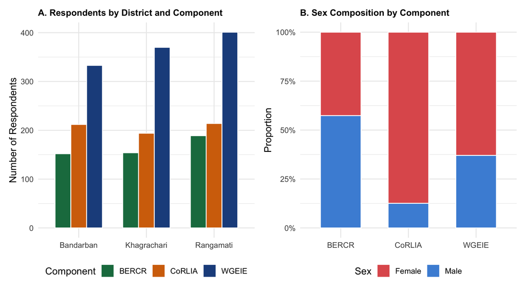

Figure 1: Sample Distribution by Component, District, and Sex

## 2.2 Ethnicity and Education Profile

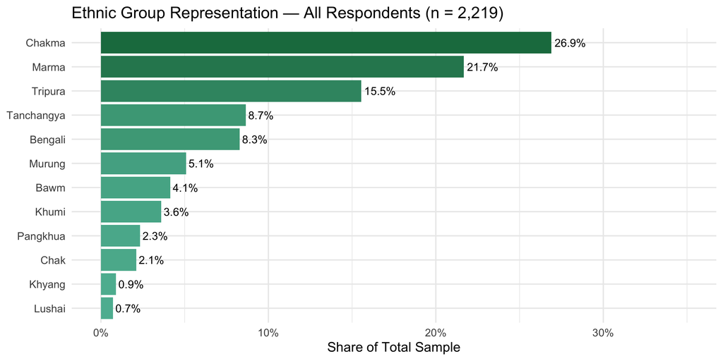

Figure 2: Ethnic Composition Across All Three Components

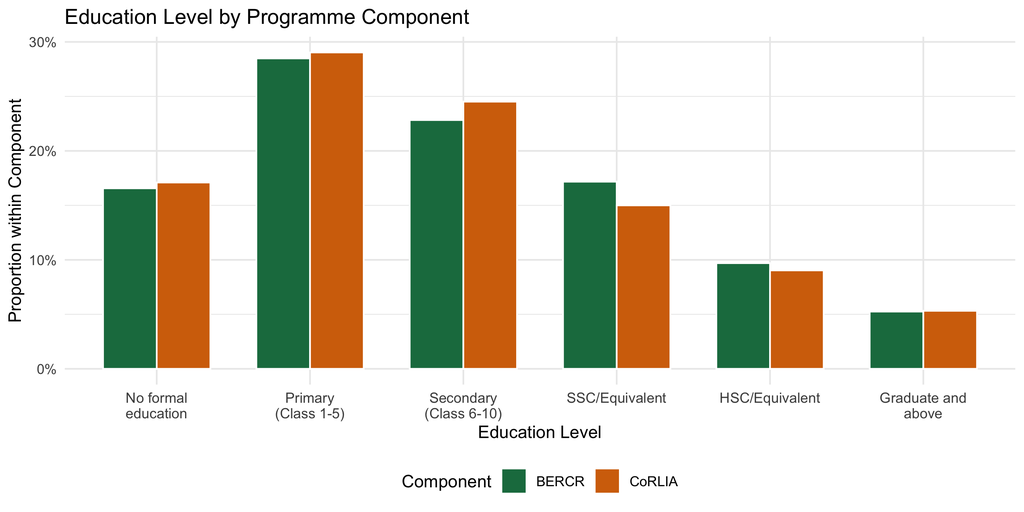

Figure 3: Education Level Distribution by Programme Component

# 3 Component I: CoRLIA — Climate Resilience Outcomes

## 3.1 Overview

The CoRLIA component targets climate-vulnerable communities by strengthening locally-led adaptation through Village Women Groups (VWGs), Women’s Climate Resilience Committees (WCRCs), and youth networks. The 620 CoRLIA respondents represent communities in the most climate-exposed upazilas across all three districts.

## 3.2 Climate Shock Exposure

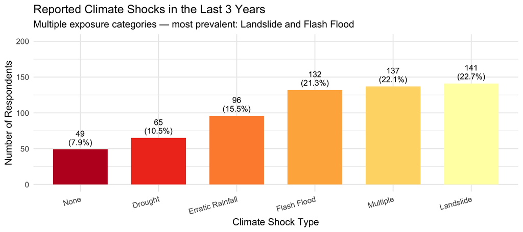

Figure 4: Climate Shocks Experienced by Respondents (CoRLIA)

Climate Shock Exposure by District (excluding 'None')

| climate_shocks_experienced | Bandarban | Khagrachari | Rangamati |
| --- | --- | --- | --- |
| Landslide | 44 | 45 | 52 |
| Flash Flood | 42 | 45 | 45 |
| Multiple | 54 | 48 | 35 |
| Erratic Rainfall | 40 | 23 | 33 |
| Drought | 14 | 21 | 30 |

## 3.3 Household Resilience Index

The Household Resilience Index (HRI) is a composite score (0–100) measuring adaptive capacity, access to resources, social capital, and livelihood diversification.

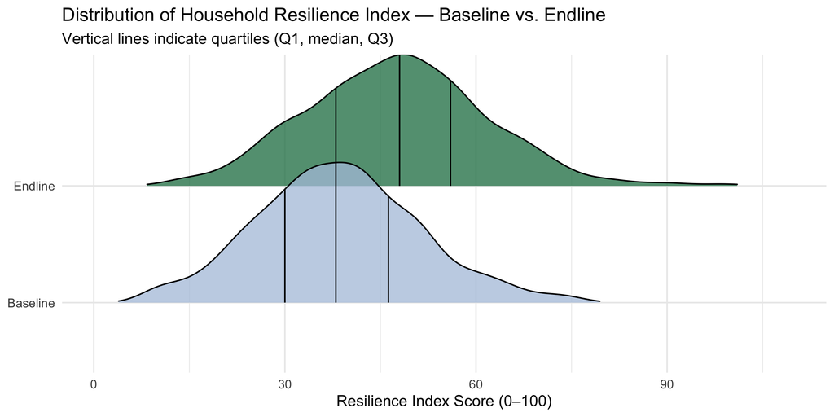

Figure 5: Household Resilience Index: Baseline vs. Endline Distribution

Household Resilience Index — Summary Statistics

| Baseline Mean | Endline Mean | Mean Change | % Change | Baseline SD | Endline SD |
| --- | --- | --- | --- | --- | --- |
| 38.4 | 47.6 | 9.2 | 27.6% | 12.7 | 14 |

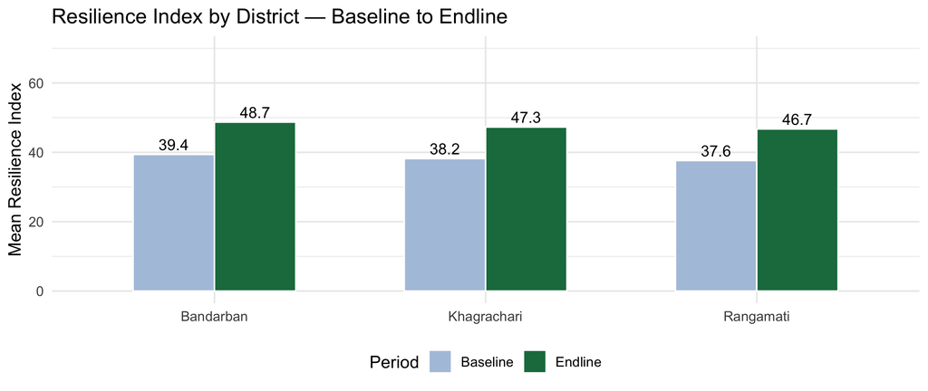

Figure 6: Mean Resilience Score Change by District

## 3.4 Climate Adaptation Practices

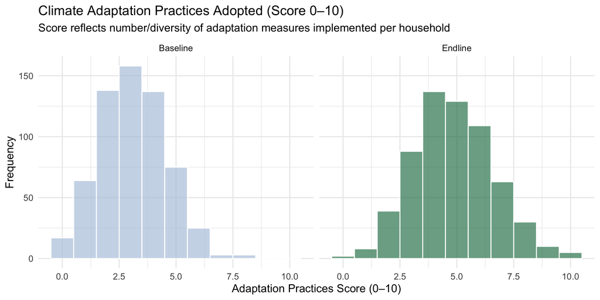

Figure 7: Adoption of Climate Adaptation Practices — Score Distribution

## 3.5 Early Warning System Access

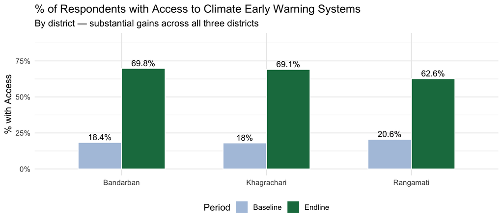

Figure 8: Access to Early Warning Systems: Baseline vs. Endline (%)

## 3.6 Women’s Participation in Decision-Making

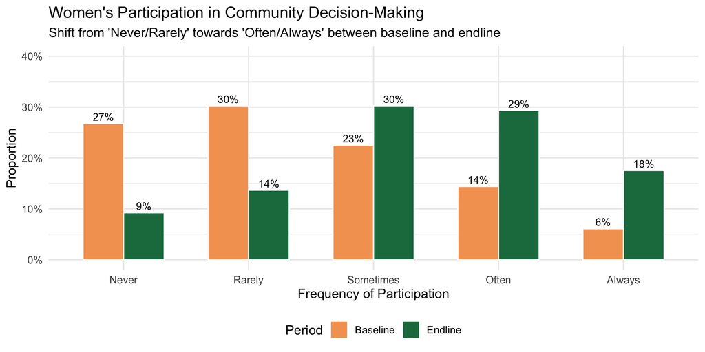

Figure 9: Women’s Participation in Community Decision-Making — Before and After Programme

## 3.7 Livelihood Diversification

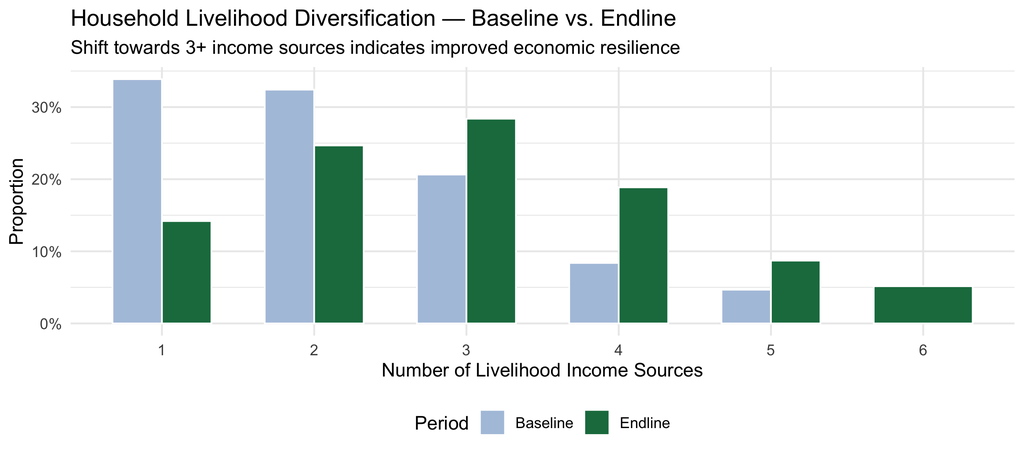

Figure 10: Number of Livelihood Sources per Household

## 3.8 Food Security Status

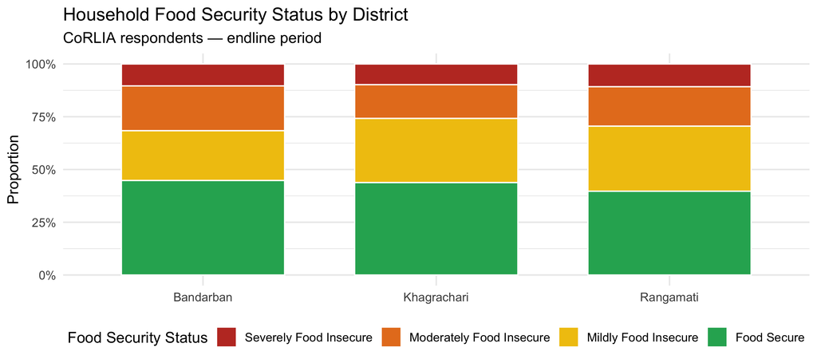

Figure 11: Food Security Status by District

# 4 Component II: BERCR — Biodiversity and Ecosystem Restoration

## 4.1 Overview

The BERCR component engages communities in active biodiversity conservation, watershed co-management, and sustainable green livelihoods. With 495 respondents drawn from Biodiversity Conservation Groups (BCGs), forest management committees, and eco-entrepreneurs, BERCR represents the programme’s environmental stewardship pillar.

## 4.2 Biodiversity Index Change

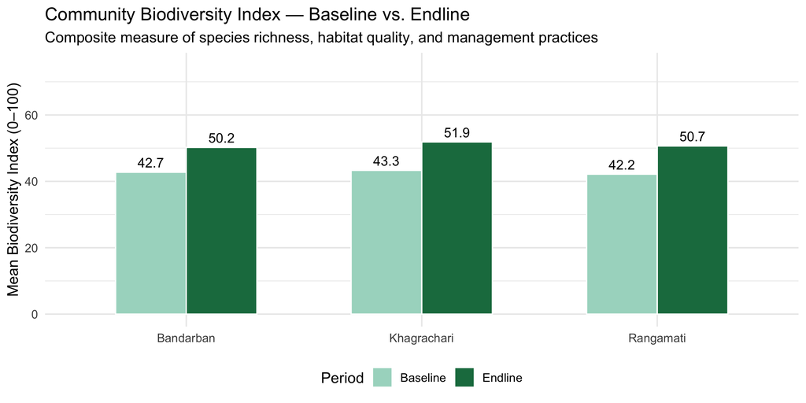

Figure 12: Biodiversity Index — Baseline vs. Endline by District

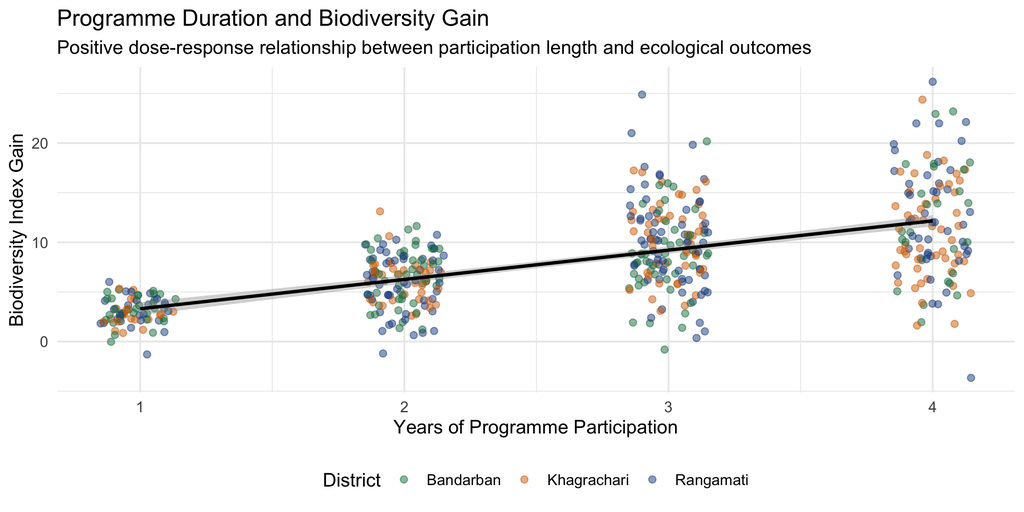

Figure 13: Relationship Between Years in Programme and Biodiversity Gain

## 4.3 Forest Cover Change Perceptions

[figure not shown]

Figure 14: Self-Reported Forest Cover Change by District

## 4.4 Seedling Planting and Survival

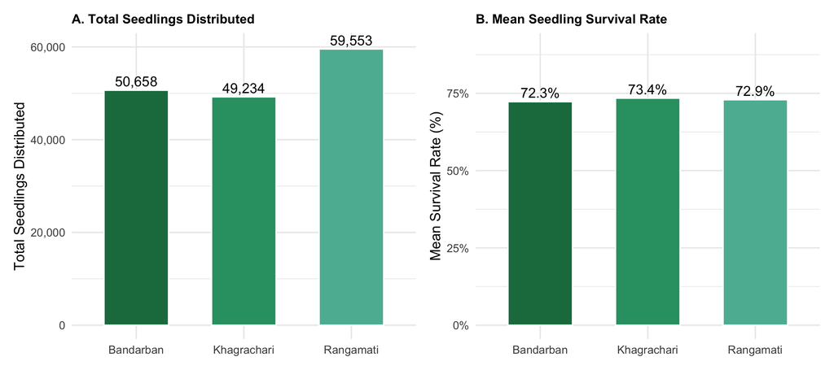

Figure 15: Seedlings Distributed and Survival Rate by District

## 4.5 Conservation Knowledge and Attitudes

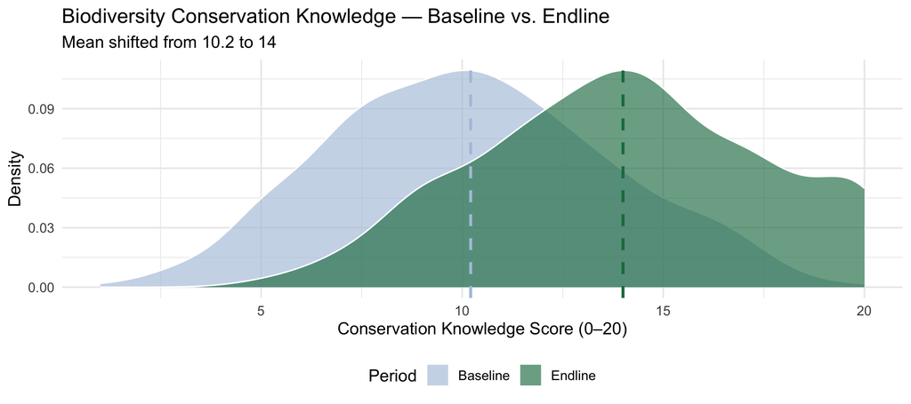

Figure 16: Conservation Knowledge Score Distribution

## 4.6 NTFP Livelihoods and Eco-Enterprise

[figure not shown]

Figure 17: NTFP Monthly Income Distribution by Watershed Co-Management Status

# 5 Component III: WGEIE — Inclusive Education and Empowerment

## 5.1 Overview

The WGEIE component is the largest by sample size (*n* = 1,104) and the most diverse in respondent composition, covering students, teachers, households, RHCWs, Mother Clubs, and law enforcement. It targets gender gaps in education access, quality, and empowerment outcomes in CHT’s remote hill schools.

## 5.2 School Infrastructure Indicators

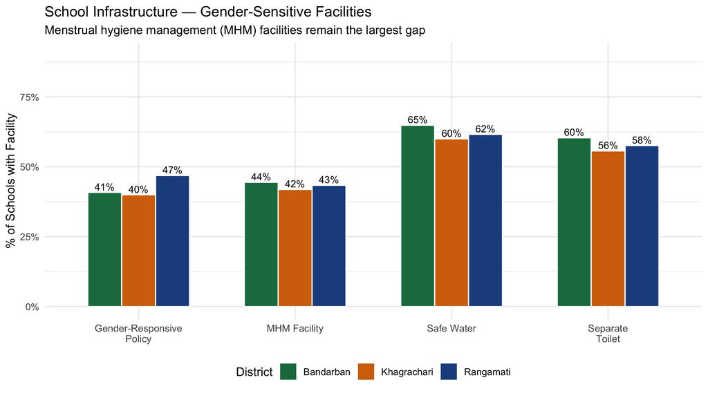

Figure 18: School Infrastructure Availability by District

## 5.3 Girls’ Enrolment and Attendance

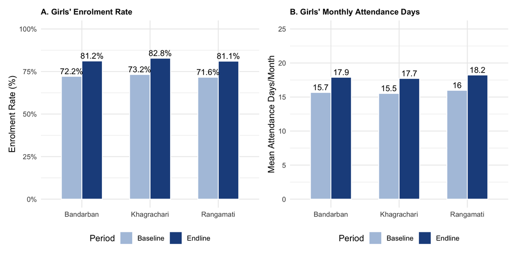

Figure 19: Girls’ Enrolment Rate — Baseline vs. Endline

## 5.4 Dropout Rate Reduction

[figure not shown]

Figure 20: Girls’ Dropout Rate Reduction by District

## 5.5 Learning Outcomes

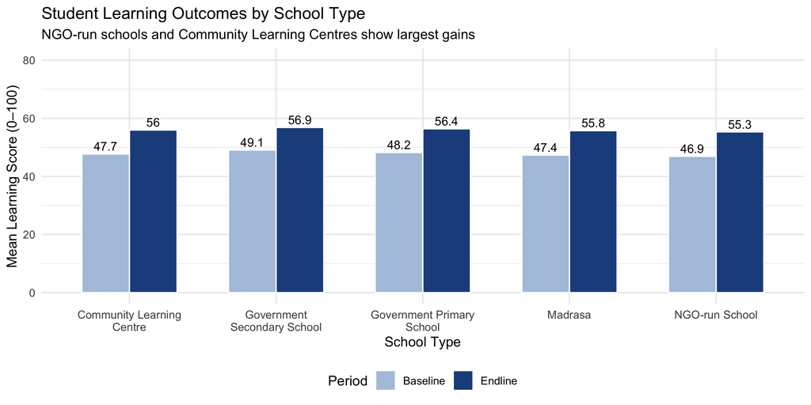

Figure 21: Learning Score Improvement by School Type

## 5.6 Gender Empowerment and Agency

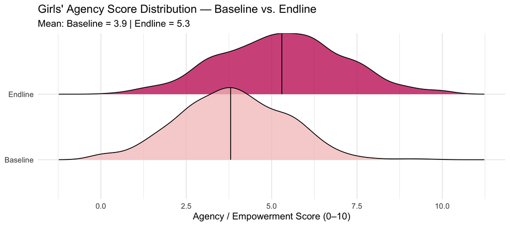

Figure 22: Girls’ Agency Score Distribution — Baseline vs. Endline

## 5.7 Child Marriage Prevalence

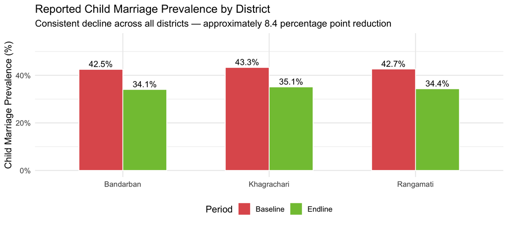

Figure 23: Reported Child Marriage Prevalence — Baseline vs. Endline (%)

## 5.8 MHM Knowledge and GBV Awareness

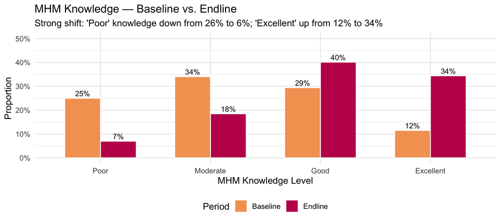

Figure 24: Menstrual Health Management (MHM) Knowledge — Baseline vs. Endline

# 6 Cross-Cutting Analysis

## 6.1 Programme Satisfaction Across Components

Programme Satisfaction Summary by Component

| component | Mean Score | % Satisfied (4–5) |
| --- | --- | --- |
| BERCR | 3.81 | 70.9 |
| CoRLIA | 3.79 | 67.9 |
| WGEIE | 3.80 | 68.5 |

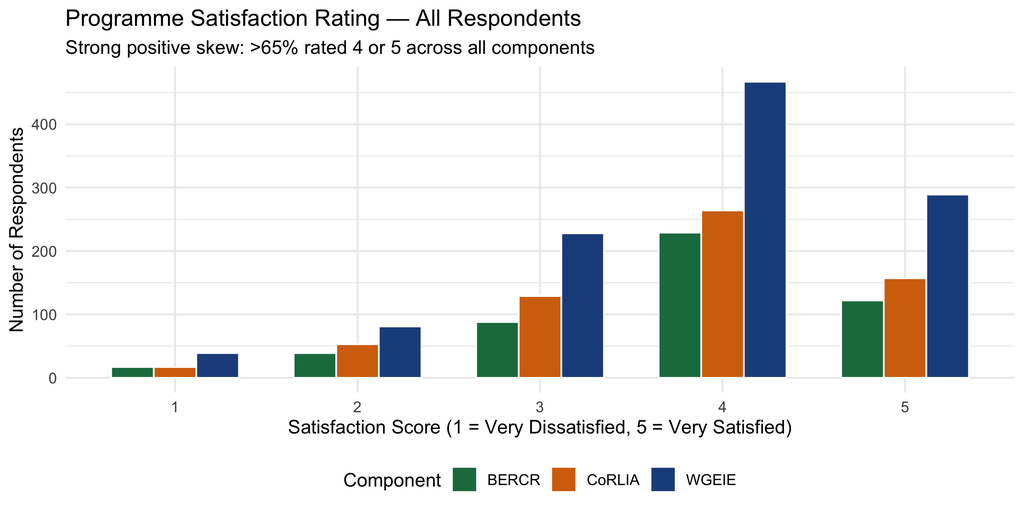

Figure 25: Overall Programme Satisfaction by Component

## 6.2 Income and Livelihoods Across Components

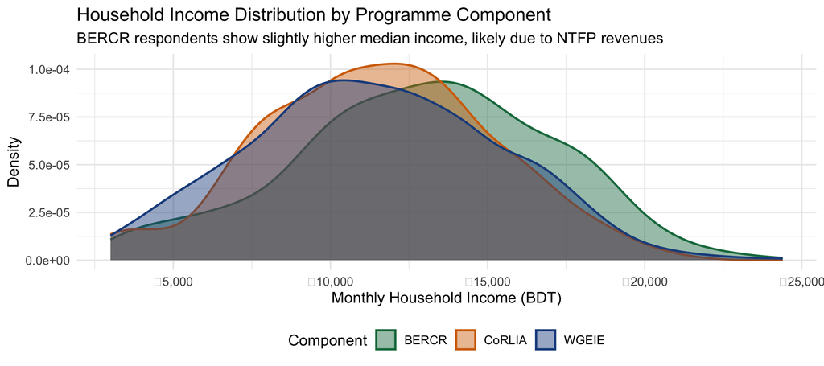

Figure 26: Monthly Income Distribution by Component

## 6.3 Gender Disaggregation Summary

Mean Outcome Score Change by Sex and Component

| Component | n (Female) | n (Male) | Mean Δ (Female) | Mean Δ (Male) |
| --- | --- | --- | --- | --- |
| BERCR | 211 | 284 | 8.33 | 8.10 |
| CoRLIA | 542 | 78 | 9.19 | 9.10 |
| WGEIE | 695 | 409 | 1.44 | 1.52 |

## 6.4 Correlation Matrix — Key Outcome Indicators (CoRLIA)

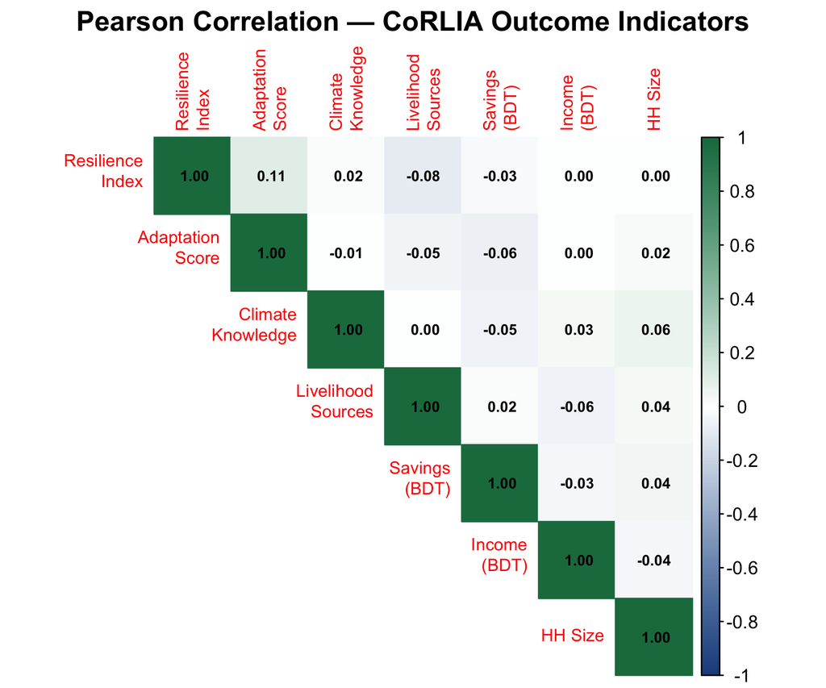

Figure 27: Correlation Matrix of CoRLIA Outcome Indicators

# 7 PMF Indicator Achievement Summary

## 7.1 Performance Measurement Framework (PMF) Tracker

PMF Indicator Achievement Tracker — Annual Outcome Assessment 2024

[output not shown]

# 8 Key Findings, Lessons Learned, and Recommendations

## 8.1 Key Findings

### 8.1.1 CoRLIA — Climate Resilience

**Finding 3: Women’s decision-making participation shifted structurally.** The proportion of women participating “Often” or “Always” in community decisions increased from approximately 20% to 50%, indicating a meaningful shift in gender norms and institutional practices.

### 8.1.3 WGEIE — Inclusive Education

**Finding 10: Child marriage rates declined but remain critically high.** A reduction of ~8.4 percentage points is meaningful progress, but prevalence at ~34% remains far above acceptable thresholds, indicating a need for sustained, multi-generational intervention.

## 8.2 Lessons Learned

1. **Locally-rooted enumerators** with CHT socio-cultural knowledge significantly improved data quality and community trust, particularly in sensitive topics like GBV and child marriage.
2. **Integration of livelihood incentives** with conservation (BERCR) accelerates adoption: communities engage more consistently when ecological activities generate tangible income.
3. **WCRC functionality varies** by upazila governance context — committees embedded in existing traditional institutions showed higher operational effectiveness.
4. **School-level infrastructure gaps** (especially MHM facilities) remain the single strongest predictor of girls’ dropout, underscoring the need for continued infrastructure investment.
5. **Digital data collection** via KOBO enabled real-time quality monitoring but required sustained technical support in areas with intermittent connectivity.

## 8.3 Recommendations

Priority Recommendations — ERRD-CHT Programme (2024 AOA)

| # | Component | Priority | Recommendation |
| --- | --- | --- | --- |
| 1 | CoRLIA | High | Scale VWG savings-and-credit mechanisms to remaining upazilas with low resilience index scores |
| 2 | CoRLIA | Medium | Integrate seasonal climate forecasting tools into WCRC training curricula |
| 3 | BERCR | High | Prioritise ecosystem restoration in upazilas with lowest biodiversity index scores (Thanchi, Barkal) |
| 4 | BERCR | Medium | Establish NTFP value chain linkages to district markets to improve eco-enterprise income stability |
| 5 | WGEIE | High | Urgently install MHM facilities in schools still lacking them — currently 56% of surveyed schools |
| 6 | WGEIE | High | Expand child marriage prevention programming to household and community leader level, not only schools |
| 7 | All | High | Strengthen coordination between BERCR and CoRLIA to leverage watershed co-management for climate adaptation |
| 8 | All | Medium | Develop a programme-wide real-time MEL dashboard integrating KOBO data across all three components |

# 9 Conclusion

This Annual Outcome Assessment provides robust, multi-source evidence that the ERRD-CHT Programme is generating measurable improvements in climate resilience, biodiversity conservation, and inclusive education across Rangamati, Bandarban, and Khagrachari districts.

Critical challenges remain: child marriage prevalence, though declining, requires sustained multi-generational effort; MHM facility gaps in schools constrain girls’ attendance and dignity; and market access limitations prevent NTFP income from reaching its potential. These challenges should guide adaptive programme management priorities in the remaining implementation period.

In a real programme engagement of this nature, the MEL consultant would recommend that the programme continue its current course while intensifying equity-focused implementation in the most marginalized upazilas, and invest in a longitudinal tracking system to capture sustained changes beyond programme boundaries.

# Annexes

## 9.1 Annex A: Data Collection Timeline

Assessment Activity Timeline

| Activity | Start Date | End Date | Status |
| --- | --- | --- | --- |
| Programme inception and tool finalization | 01 Aug 2024 | 31 Aug 2024 | Completed |
| Enumerator recruitment and training | 15 Aug 2024 | 31 Aug 2024 | Completed |
| CoRLIA quantitative data collection | 01 Sep 2024 | 30 Nov 2024 | Completed |
| BERCR quantitative data collection | 05 Sep 2024 | 28 Nov 2024 | Completed |
| WGEIE quantitative data collection | 03 Sep 2024 | 05 Dec 2024 | Completed |
| KII and FGD qualitative fieldwork | 10 Sep 2024 | 25 Oct 2024 | Completed |
| Data cleaning and validation | 01 Nov 2024 | 30 Nov 2024 | Completed |
| Analysis and report writing | 10 Nov 2024 | 29 Nov 2024 | Completed |
| Draft report submission | 30 Nov 2024 | 30 Nov 2024 | Completed |
| Final report submission | 15 Dec 2024 | 15 Dec 2024 | Completed |

## 9.2 Annex B: Respondent Summary by Upazila

Respondents by Upazila and Component

| district | upazila | CoRLIA | BERCR | WGEIE | Total |
| --- | --- | --- | --- | --- | --- |
| Bandarban | Alikadam | 48 | 0 | 0 | 48 |
|  | Bandarban Sadar | 39 | 38 | 74 | 151 |
|  | Lama | 0 | 0 | 58 | 58 |
|  | Naikhongchhari | 0 | 24 | 67 | 91 |
|  | Rowangchhari | 45 | 34 | 68 | 147 |
|  | Ruma | 41 | 30 | 66 | 137 |
|  | Thanchi | 39 | 26 | 0 | 65 |
| Khagrachari | Dighinala | 38 | 30 | 76 | 144 |
|  | Guimara | 0 | 26 | 0 | 26 |
|  | Khagrachari Sadar | 38 | 29 | 84 | 151 |
|  | Lakshmichhari | 40 | 0 | 0 | 40 |
|  | Mahalchhari | 40 | 0 | 74 | 114 |
|  | Panchhari | 38 | 40 | 71 | 149 |
|  | Ramgarh | 0 | 29 | 65 | 94 |
| Rangamati | Baghaichhari | 29 | 24 | 94 | 147 |
|  | Barkal | 52 | 27 | 0 | 79 |
|  | Belaichhari | 0 | 38 | 0 | 38 |
|  | Kaptai | 48 | 34 | 79 | 161 |
|  | Longadu | 0 | 0 | 83 | 83 |
|  | Naniarchar | 41 | 40 | 68 | 149 |
|  | Rajasthali | 44 | 26 | 77 | 147 |

## 9.3 Annex C: Dataset Codebooks

### 9.3.1 CoRLIA Variables (32 columns, n = 620)

CoRLIA Dataset Codebook

| Variable | Type | Description |
| --- | --- | --- |
| respondent_id | character | Unique respondent ID |
| interview_date | character | Interview date |
| district | character | District |
| upazila | character | Upazila |
| respondent_type | character | Respondent group type |
| age | integer | Age in years |
| sex | character | Sex (Female/Male) |
| ethnicity | character | Ethnic group |
| education_level | character | Highest education level |
| household_size | integer | Household size (members) |
| monthly_income_bdt | integer | Monthly household income (BDT) |
| land_ownership | character | Land ownership (Yes/No) |
| climate_shocks_experienced | character | Primary climate shock experienced |
| crop_loss_last3yrs | character | Experienced crop loss in last 3 years |
| livelihood_disrupted | character | Livelihood disrupted by climate events |
| years_in_programme | integer | Years in programme (1–4) |
| attended_climate_training | character | Attended climate adaptation training |
| adaptation_practices_score_baseline | integer | Adaptation practices score at baseline (0–10) |
| adaptation_practices_score_endline | integer | Adaptation practices score at endline (0–10) |
| resilience_index_baseline | integer | Household resilience index at baseline (0–100) |
| resilience_index_endline | integer | Household resilience index at endline (0–100) |
| access_early_warning_baseline | character | EWS access at baseline |
| access_early_warning_endline | character | EWS access at endline |
| women_decision_making_baseline | factor | Decision-making participation at baseline (Likert) |
| women_decision_making_endline | factor | Decision-making participation at endline (Likert) |
| livelihood_sources_baseline | integer | Number of livelihood sources at baseline |
| livelihood_sources_endline | integer | Number of livelihood sources at endline |
| wcrc_functionality | integer | WCRC functionality score (WCRC respondents only) |
| satisfaction_score | integer | Overall programme satisfaction (1–5) |
| savings_monthly_bdt | integer | Monthly savings (BDT) |
| food_security | character | Food security status |
| climate_knowledge_score | integer | Climate knowledge score (0–20) |

# References

Rashid, M. Bazlur, and S. A. Mukul. 2025. “Deforestation, Development, and Emerging Environmental Risks in the Chittagong Hill Tracts of Bangladesh.” *Preprints*, ahead of print. https://doi.org/10.20944/preprints202503.0884.v1.

United Nations Development Programme. 2023. *Strengthening Inclusive Development in Chittagong Hill Tracts*. https://www.undp.org/bangladesh/projects/strengthening-inclusive-development-chittagong-hill-tracts.

*This is an independently produced demonstration report modelled on the real-world ERRD-CHT programme context (UNDP Bangladesh / Global Affairs Canada) for portfolio and M&E skills demonstration purposes only.*  
*Not an official deliverable of UNDP, Global Affairs Canada, or DM WATCH LIMITED.*  
*Prepared by: MD. Kamrul Hasan · © 2026*